# Classification patients vs. témoins

Xian YANG

19 juillet 2017

## Hiérarchisation des critères par leur sensibilité pour schizophrènes vs. dépressifs

C’est la continuation du travail de la semaine dernière. Cette fois-ci, les analyses sont transmises au jeu de données “V3” (donc avec 6 patients de plus). Pour l’intégralité de l’article on reprend d’abord l’hiérarchisation patients vs. témoins, puis la compare avec la nouvelle hiérarchisation schizophrènes vs. dépressifs.  
Le test utilisé est toujours celui de Man-Whitney.

### Barplots des critères dans l’ordre décroissant de leur importance, Témoins vs. Patients

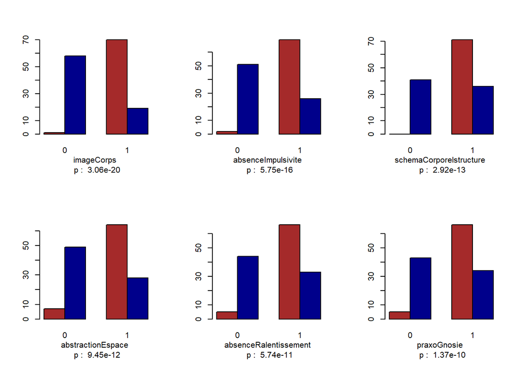

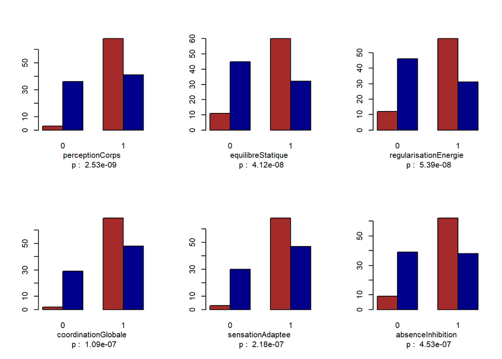

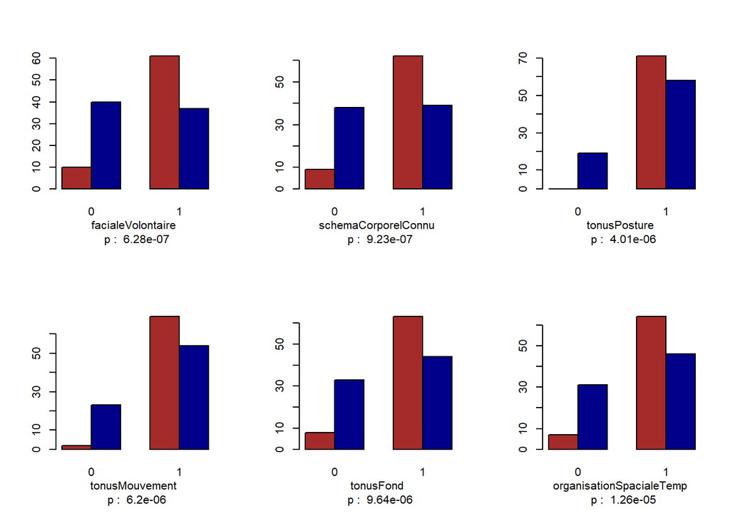

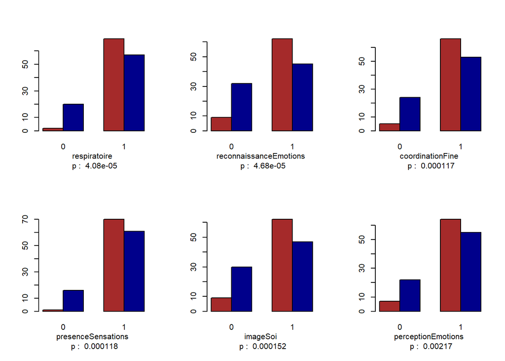

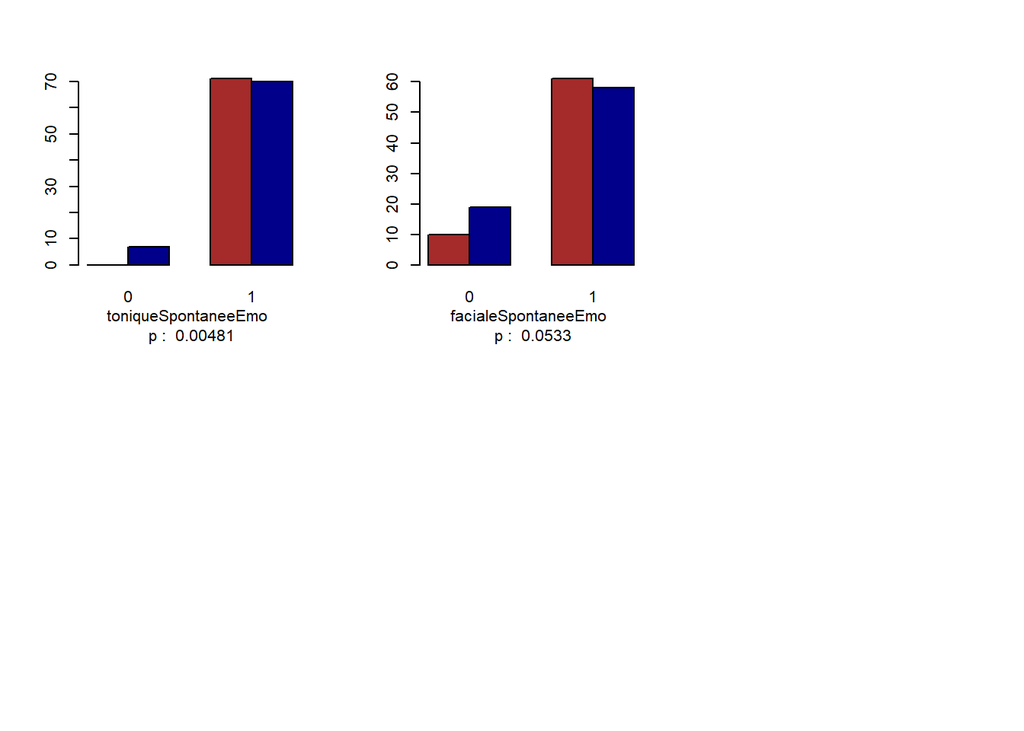

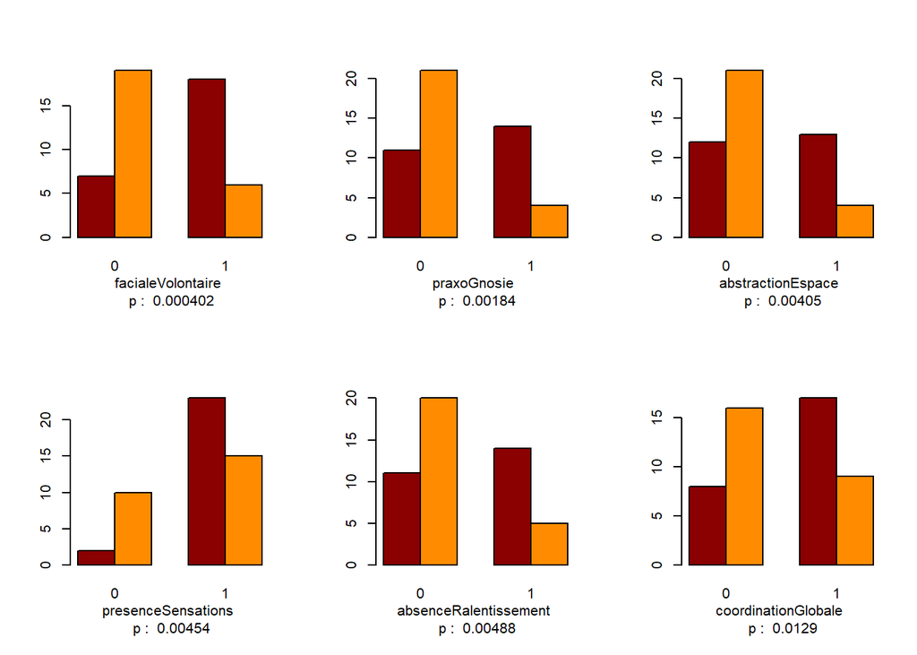

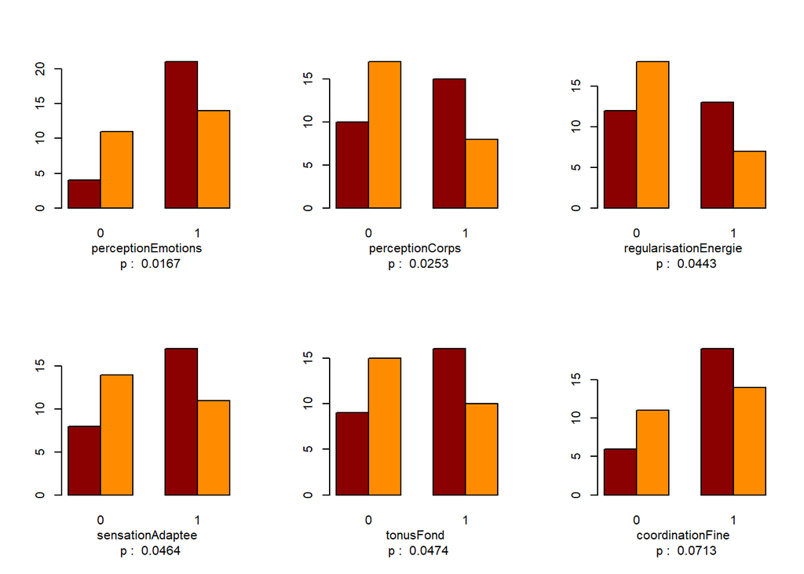

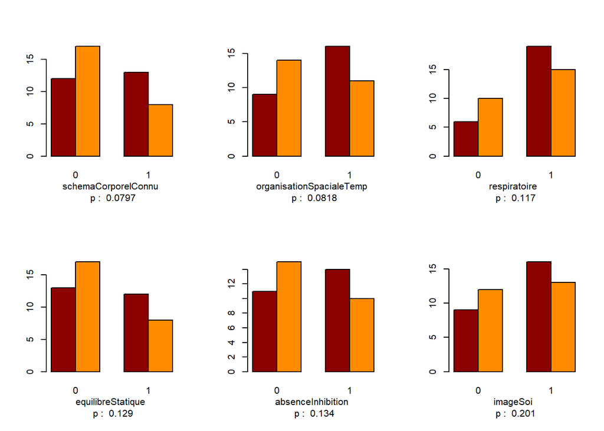

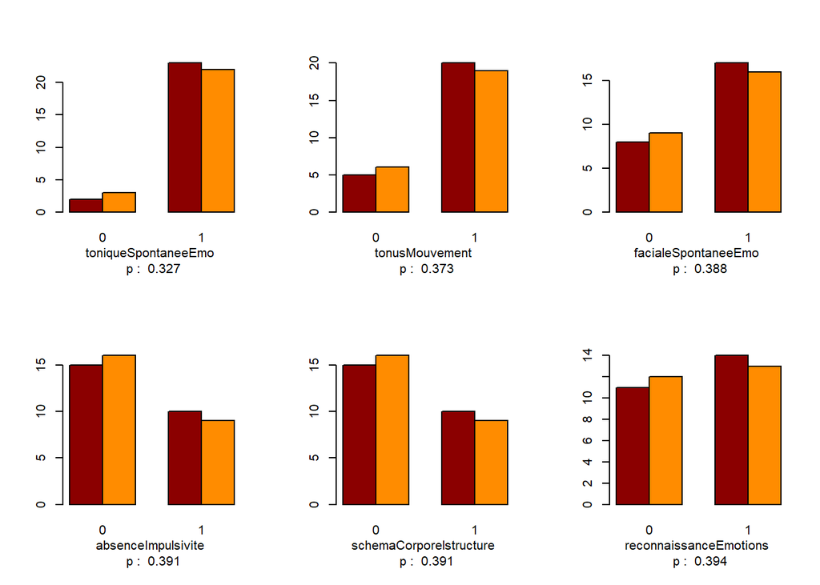

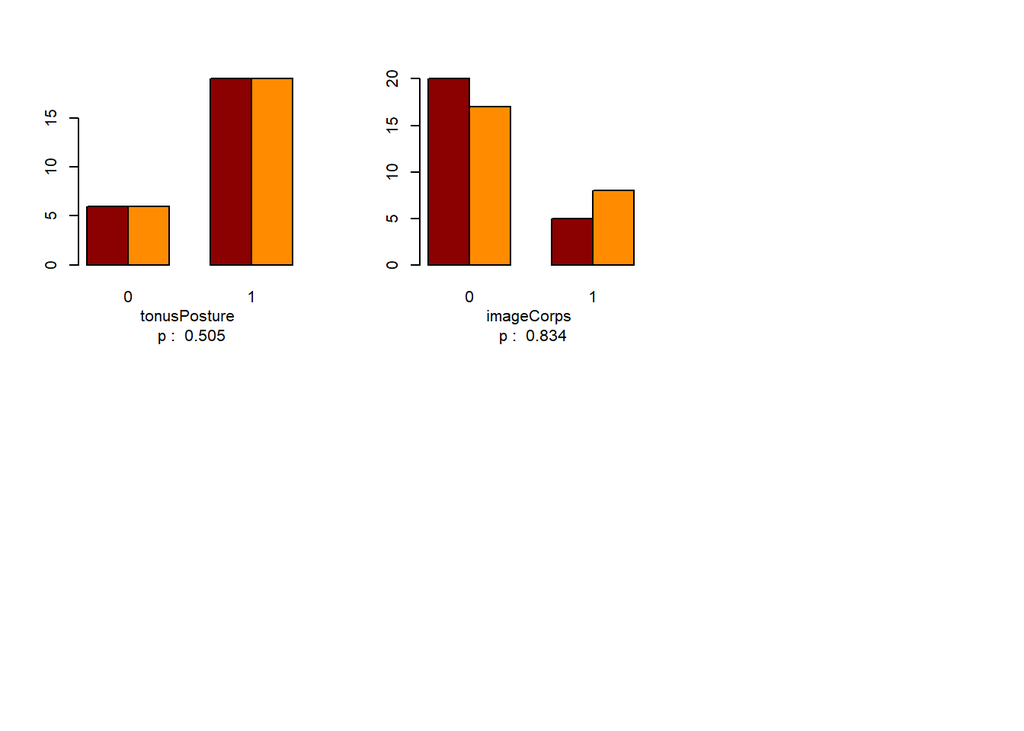

Quels sont les critères ayant une grande augmentation ou descende en termes de rang de sensibilité ( >= 5) ?

```
## presenceSensations
##  Son rang dans le test Patients vs. Témoins est 22 avec une p-valeur 0.000118
##  Son rang dans le test Schizo. vs. Dépr. est 4 avec une p-valeur 0.00454
##
## imageCorps
##  Son rang dans le test Patients vs. Témoins est 1 avec une p-valeur 3.06e-20
##  Son rang dans le test Schizo. vs. Dépr. est 26 avec une p-valeur 0.834
##
## perceptionEmotions
##  Son rang dans le test Patients vs. Témoins est 24 avec une p-valeur 0.00217
##  Son rang dans le test Schizo. vs. Dépr. est 7 avec une p-valeur 0.0167
##
## absenceImpulsivite
##  Son rang dans le test Patients vs. Témoins est 2 avec une p-valeur 5.75e-16
##  Son rang dans le test Schizo. vs. Dépr. est 22 avec une p-valeur 0.391
##
## tonusPosture
##  Son rang dans le test Patients vs. Témoins est 15 avec une p-valeur 4.01e-06
##  Son rang dans le test Schizo. vs. Dépr. est 25 avec une p-valeur 0.505
##
## equilibreStatique
##  Son rang dans le test Patients vs. Témoins est 8 avec une p-valeur 4.12e-08
##  Son rang dans le test Schizo. vs. Dépr. est 16 avec une p-valeur 0.129
##
## coordinationFine
##  Son rang dans le test Patients vs. Témoins est 21 avec une p-valeur 0.000117
##  Son rang dans le test Schizo. vs. Dépr. est 12 avec une p-valeur 0.0713
##
## facialeVolontaire
##  Son rang dans le test Patients vs. Témoins est 13 avec une p-valeur 6.28e-07
##  Son rang dans le test Schizo. vs. Dépr. est 1 avec une p-valeur 0.000402
##
## tonusFond
##  Son rang dans le test Patients vs. Témoins est 17 avec une p-valeur 9.64e-06
##  Son rang dans le test Schizo. vs. Dépr. est 11 avec une p-valeur 0.0474
##
## imageSoi
##  Son rang dans le test Patients vs. Témoins est 23 avec une p-valeur 0.000152
##  Son rang dans le test Schizo. vs. Dépr. est 18 avec une p-valeur 0.201
##
## schemaCorporelstructure
##  Son rang dans le test Patients vs. Témoins est 3 avec une p-valeur 2.92e-13
##  Son rang dans le test Schizo. vs. Dépr. est 23 avec une p-valeur 0.391
##
## absenceInhibition
##  Son rang dans le test Patients vs. Témoins est 12 avec une p-valeur 4.53e-07
##  Son rang dans le test Schizo. vs. Dépr. est 17 avec une p-valeur 0.134
##
## facialeSpontaneeEmo
##  Son rang dans le test Patients vs. Témoins est 26 avec une p-valeur 0.0533
##  Son rang dans le test Schizo. vs. Dépr. est 21 avec une p-valeur 0.388
##
## toniqueSpontaneeEmo
##  Son rang dans le test Patients vs. Témoins est 25 avec une p-valeur 0.00481
##  Son rang dans le test Schizo. vs. Dépr. est 19 avec une p-valeur 0.327
```

Il convient de remarquer que la sensibilité des critères entre patients et témoins est en général beacoup plus importante que celle entre schizophrènes et dépressifs. Ça veut dire qu’un rang très en arrière en termes de patients vs. témoins n’implique pas forcément une sensibilité plus faible qu’un rang très en avant en termes de schizophrènes vs. dépressifs. Un bon exemple est le premier résultat si-dessus.

## Méthode 1 (famille) : Classification patients vs. témoins par méthode de régression logistique

La semaine dernière on a constaté, dans le graphique d’ACP, que les patients et les témoins se regroupent entre eux (en revanche ce n’est apparemment pas le cas de schizophrènes vs. dépressifs). On peut donc penser à trouver une méthode, qui sert à classfier un sujet dans le sous-groupe patients ou le sous-groupe témoins uniquement à partir de ses résultats psychomoteurs. L’étude du problème de classification schizoprènes vs. dépressifs étant plus difficile à cause d’un considérable mélange l’un dans l’autre, je la laisse pour la sémaine prochaine.

Pour l’instant, on se concentre principalement sur la qualité des différentes méthodes de classification. Ceci pour l’instant toujours à l’aide de la table d’erreurs de la prédiction de la méthode. Les détailles mathématiques de chaque méthode seront mises en évidence plus tard mais, ne sont pas notre première priorité pour le moment.

On verra dans la suite que certaines méthodes délivrent des résultats plus robustes que les autres. Sachant qu’aucune méthode puisse toujours donner une réponse parfaite sans erreur, on verra également que certaines méthodes préfèrent donner de faux positifs alors que certaines préfèrent donner de faux négatifs. On pourra donc poser la question : peut-on camparer et combiner de différentes méthodes avec de préférences opposées, de façon que le résultat de prédiction puisse être amlioré ? Cette question est très intéressante et sera aussi être étudiée une autre fois.

### Méthode de travail

En principe, d’ailleurs pour les autres familles de méthodes statistiques dans la suite aussi, je découpe au hasard l’ensemble des sujets en 2 parties, un jeu d’entraînement et un jeu de test, de manière que le jeu de test est composé de 25 patients et 25 témoins. Il y a donc 52 patients et 46 témoins dans le jeu d’entraînement. J’étudie d’abord un classifieur (une règle de classification, ou encore une frontière) sur le jeu d’entraïnement, c’est-à-dire sans connaitre au préalable aucune information sur lees sujets qui se trouvent dans le jeu de test. En suite, je vérifierai ce classifieur sur le jeu de test, pour en tirer la table d’erreurs. Cette table d’erreurs est une très bonne mesure de la qualité de prédiction de la méthode, qui comprend toutefois du hasard car les membres du jeu de test sont choisis au hasard. Je répète donc 3 fois cette procédure, afin que l’erreur aléatoire reste relativement minuscule.

### Régression logistique simple

Une centaine d’observations contre 26 variables, le graphique patients vs. témoins possédant une forme qui ne s’oppose pas de façon considérable à une frontière linéaire, tout ça nous dit de commencer par les méthodes linéraies les plus classiques : régression logistique. On montre tout d’abord la variante la plus simple, i.e. la régression logistique sans régularisation. Cependant, il convient de savoir que, pour un problème de classification à 26 variables et 98 observations, qui subit en plus pas mal de co-linéarité puisque les scores ne sont que binaires, la dimension (nombre de variable) est sans doute un peu trop élevée pour le nombre d’observation. Il en résulte que sans régularisation, la régression logistique va être parfaitement performante sur le jeu d’entraînement (aucune faute), alors qu’elle est susceptible d’avoir une mauvaise qualité de prédiction. On parle d’un sur-appretissage.

```
##
## Call:
## glm(formula = patient ~ ., family = binomial, data = jeuEntraine)
##
## Deviance Residuals:
##        Min          1Q      Median          3Q         Max
## -2.773e-05  -2.110e-08   2.110e-08   2.110e-08   2.774e-05
##
## Coefficients:
##                            Estimate Std. Error z value Pr(>|z|)
## (Intercept)                 213.053 649679.880   0.000    1.000
## presenceSensations          -18.294 189373.018   0.000    1.000
## imageCorps                  -47.707 111650.142   0.000    1.000
## perceptionEmotions            3.972 235744.488   0.000    1.000
## absenceImpulsivite          -85.208  99590.774  -0.001    0.999
## tonusPosture                -22.662 346302.067   0.000    1.000
## equilibreStatique           -38.112 127922.067   0.000    1.000
## coordinationGlobale         -13.726 296137.869   0.000    1.000
## coordinationFine             40.426 126466.517   0.000    1.000
## facialeVolontaire           -56.631 210215.717   0.000    1.000
## reconnaissanceEmotions      -11.316 169816.662   0.000    1.000
## tonusMouvement              -35.090 450045.582   0.000    1.000
## absenceRalentissement        60.902 168743.330   0.000    1.000
## sensationAdaptee             12.332 175738.370   0.000    1.000
## tonusFond                   -14.938 147882.583   0.000    1.000
## imageSoi                     12.623 151259.648   0.000    1.000
## schemaCorporelConnu           1.569 188503.923   0.000    1.000
## schemaCorporelstructure     -27.296 182313.025   0.000    1.000
## abstractionEspace           -74.664 109232.247  -0.001    0.999
## organisationSpacialeTemp    -12.158  98920.116   0.000    1.000
## praxoGnosie                 -10.741 116737.497   0.000    1.000
## regularisationEnergie       -41.058 111412.912   0.000    1.000
## perceptionCorps              54.623 197320.777   0.000    1.000
## absenceInhibition            44.091 280336.476   0.000    1.000
## respiratoire                -14.237 212978.501   0.000    1.000
## facialeSpontaneeEmo         -22.408 232168.957   0.000    1.000
## toniqueSpontaneeEmo          -6.312 629738.491   0.000    1.000
##
## (Dispersion parameter for binomial family taken to be 1)
##
##     Null deviance: 1.3549e+02  on 97  degrees of freedom
## Residual deviance: 4.8080e-09  on 71  degrees of freedom
## AIC: 54
##
## Number of Fisher Scoring iterations: 25
```

On observe qu’aucun coefficient n’est significatif ! Cela mène à une prédiction d’une relativement mauvaise qualité :

```
##          Prédiction
## Réalité patient temoin
##   temoin        1     24
##   patient      20      5
```

```
##          Prédiction
## Réalité patient temoin
##   temoin        3     22
##   patient      20      5
```

```
##          Prédiction
## Réalité patient temoin
##   temoin        0     25
##   patient      23      2
```

### Régression logistique avec régularisation Lasso

```
##            Length Class  Mode
## lambda     83     -none- numeric
## cvm        83     -none- numeric
## cvsd       83     -none- numeric
## cvup       83     -none- numeric
## cvlo       83     -none- numeric
## nzero      83     -none- numeric
## name        1     -none- character
## glmnet.fit 13     lognet list
## lambda.min  1     -none- numeric
## lambda.1se  1     -none- numeric
```

```
## [1] 0.02163561
```

```
## 27 x 1 sparse Matrix of class "dgCMatrix"
##                                    1
## (Intercept)               3.27287110
## presenceSensations        .
## imageCorps               -1.76708998
## perceptionEmotions        .
## absenceImpulsivite       -0.95621540
## tonusPosture              .
## equilibreStatique        -0.04486804
## coordinationGlobale       .
## coordinationFine          .
## facialeVolontaire         .
## reconnaissanceEmotions    .
## tonusMouvement            .
## absenceRalentissement     .
## sensationAdaptee          .
## tonusFond                 .
## imageSoi                  .
## schemaCorporelConnu       .
## schemaCorporelstructure  -0.98482691
## abstractionEspace        -0.57566805
## organisationSpacialeTemp  .
## praxoGnosie              -0.28279029
## regularisationEnergie     .
## perceptionCorps           .
## absenceInhibition         .
## respiratoire              .
## facialeSpontaneeEmo       .
## toniqueSpontaneeEmo       .
```

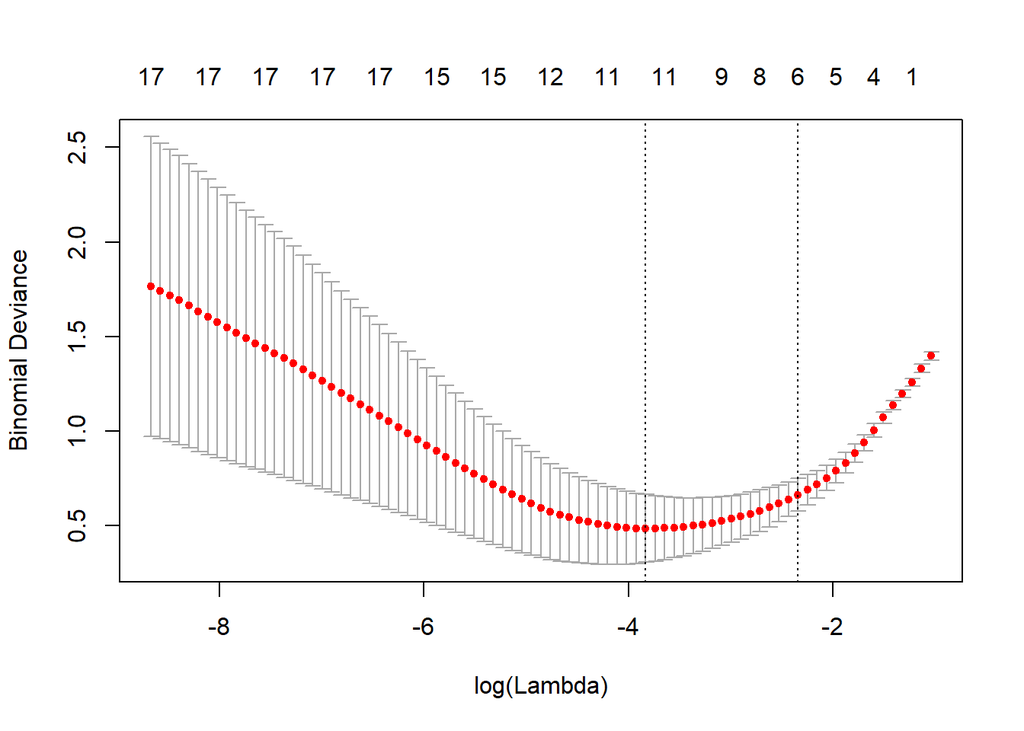

```
##          Prédiction
## Réalité patient temoin
##   temoin        0     25
##   patient      24      1
```

```
##          Prédiction
## Réalité patient temoin
##   temoin        0     25
##   patient      25      0
```

```
##          Prédiction
## Réalité patient temoin
##   temoin        0     25
##   patient      24      1
```

### Régression logistique avec régularisation Ridge

```
##            Length Class  Mode
## lambda     100    -none- numeric
## cvm        100    -none- numeric
## cvsd       100    -none- numeric
## cvup       100    -none- numeric
## cvlo       100    -none- numeric
## nzero      100    -none- numeric
## name         1    -none- character
## glmnet.fit  13    lognet list
## lambda.min   1    -none- numeric
## lambda.1se   1    -none- numeric
```

```
## [1] 0.01873817
```

```
## 27 x 1 sparse Matrix of class "dgCMatrix"
##                                     1
## (Intercept)               9.789035291
## presenceSensations       -0.467435901
## imageCorps               -1.486209448
## perceptionEmotions       -0.440793212
## absenceImpulsivite       -1.330243337
## tonusPosture             -1.081134540
## equilibreStatique        -0.588636171
## coordinationGlobale      -0.220198243
## coordinationFine          0.006278285
## facialeVolontaire        -0.527593521
## reconnaissanceEmotions   -0.344546877
## tonusMouvement           -0.581368111
## absenceRalentissement    -0.134879092
## sensationAdaptee         -0.520648461
## tonusFond                -0.257456530
## imageSoi                 -0.289122778
## schemaCorporelConnu      -0.288096964
## schemaCorporelstructure  -0.980133335
## abstractionEspace        -0.748268632
## organisationSpacialeTemp -0.341449536
## praxoGnosie              -0.371225367
## regularisationEnergie    -0.457982956
## perceptionCorps          -0.375433165
## absenceInhibition         0.237426819
## respiratoire             -0.214969828
## facialeSpontaneeEmo      -0.173675396
## toniqueSpontaneeEmo      -0.480738481
```

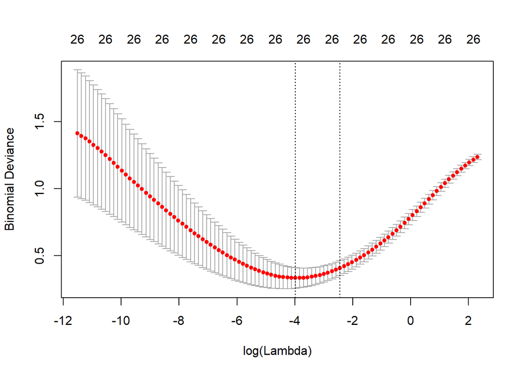

```
##          Prédiction
## Réalité patient temoin
##   temoin        0     25
##   patient      24      1
```

```
##          Prédiction
## Réalité patient temoin
##   temoin        1     24
##   patient      25      0
```

```
##          Prédiction
## Réalité patient temoin
##   temoin        0     25
##   patient      24      1
```

### Régression logistique avec régularisation réseau élastique (elastic net)

```
## [1] 0.01706706
```

```
## 27 x 1 sparse Matrix of class "dgCMatrix"
##                                    1
## (Intercept)               7.81329520
## presenceSensations       -0.37697496
## imageCorps               -2.10671091
## perceptionEmotions       -0.09712843
## absenceImpulsivite       -1.72138236
## tonusPosture             -0.92973322
## equilibreStatique        -0.73021712
## coordinationGlobale       .
## coordinationFine          .
## facialeVolontaire        -0.42937241
## reconnaissanceEmotions   -0.23557850
## tonusMouvement           -0.06846382
## absenceRalentissement     .
## sensationAdaptee         -0.32155654
## tonusFond                 .
## imageSoi                  .
## schemaCorporelConnu       .
## schemaCorporelstructure  -1.48280206
## abstractionEspace        -1.00061494
## organisationSpacialeTemp  .
## praxoGnosie              -0.36501837
## regularisationEnergie    -0.42521059
## perceptionCorps          -0.17863217
## absenceInhibition         .
## respiratoire              .
## facialeSpontaneeEmo       .
## toniqueSpontaneeEmo       .
```

```
##          Prédiction
## Réalité patient temoin
##   temoin        0     25
##   patient      24      1
```

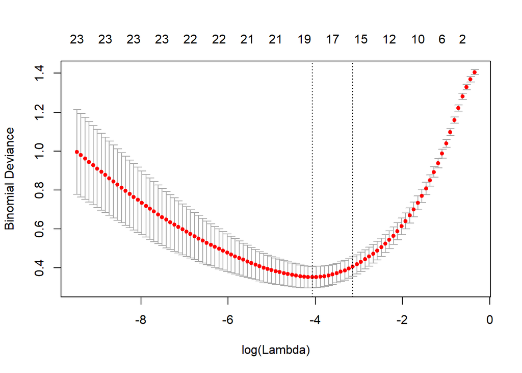

### Et si on fait varier aussi alpha ?

```
##          Prédiction
## Réalité temoin patient
##   temoin      25       0
##   patient      1      24
```

```
##    alpha lambda
## 11  0.05      1
```

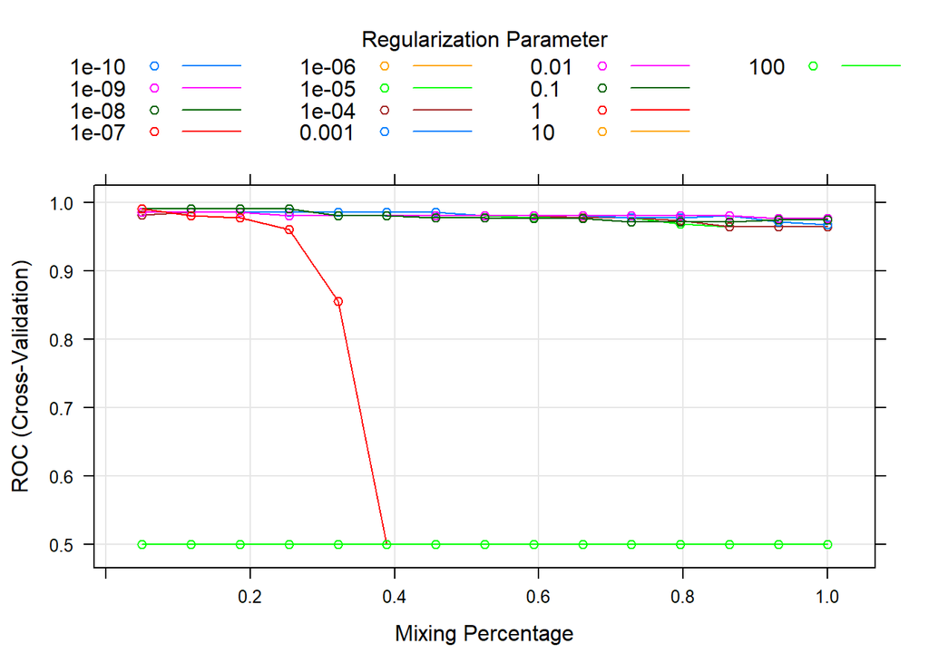

## Méthode 2 (famille) : Classification patients vs. témoins par méthode de SVM

### SVM avec le noyau radial

```
##
## Parameter tuning of 'svm':
##
## - sampling method: 10-fold cross validation
##
## - best parameters:
##  cost gamma
##     5   0.2
##
## - best performance: 0.1755556
##
## - Detailed performance results:
##        cost gamma     error dispersion
## 1      0.04   0.2 0.5533333  0.1963871
## 2      0.20   0.2 0.3188889  0.1463830
```

[output cut: 52 more lines]

```
##          Prédiction
## Réalité temoin patient
##   temoin      17       8
##   patient      0      25
```

```
##          Prédiction
## Réalité temoin patient
##   temoin      17       8
##   patient      0      25
```

[output not shown]

```
##          Prédiction
## Réalité temoin patient
##   temoin      17       8
##   patient      0      25
```

```
##          Prédiction
## Réalité temoin patient
##   temoin      18       7
##   patient      1      24
```

```
##          Prédiction
## Réalité temoin patient
##   temoin      14      11
##   patient      1      24
```

### SVM avec le noyau polynomial

```
##          Prédiction
## Réalité temoin patient
##   temoin      25       0
##   patient      5      20
```

```
##          Prédiction
## Réalité temoin patient
##   temoin      25       0
##   patient      3      22
```

```
##          Prédiction
## Réalité temoin patient
##   temoin      25       0
##   patient      4      21
```

### SVM avec le noyau linéaire

Ceci est avec le noyau linéaire.

```
##          Prédiction
## Réalité temoin patient
##   temoin      25       0
##   patient      1      24
```

```
##          Prédiction
## Réalité temoin patient
##   temoin      25       0
##   patient      0      25
```

```
##          Prédiction
## Réalité temoin patient
##   temoin      24       1
##   patient      1      24
```

### SVM avec le noyau sigmoïde

```
##          Prédiction
## Réalité temoin patient
##   temoin      22       3
##   patient      1      24
```

```
##          Prédiction
## Réalité temoin patient
##   temoin      24       1
##   patient      0      25
```

```
##          Prédiction
## Réalité temoin patient
##   temoin      25       0
##   patient      2      23
```

## Méthode 3 (famille) : méthode d’analyse discriminante

### Analyse discriminante linéaire

```
##          pred
## true      temoin patient
##   temoin      25       0
##   patient      3      22
```

```
##          pred
## true      temoin patient
##   temoin      25       0
##   patient      2      23
```

```
##          pred
## true      temoin patient
##   temoin      25       0
##   patient      2      23
```

### Analyse discriminante combinée

```
##          pred
## true      temoin patient
##   temoin      25       0
##   patient      3      22
```

```
##          pred
## true      temoin patient
##   temoin      24       1
##   patient      0      25
```

```
##          pred
## true      temoin patient
##   temoin      24       1
##   patient      1      24
```

## Méthode 4 : méthode de décision d’arbres

```
##
## Classification tree:
## tree(formula = patient ~ ., data = jeuEntraine)
## Variables actually used in tree construction:
## [1] "imageCorps"              "absenceImpulsivite"
## [3] "facialeVolontaire"       "schemaCorporelstructure"
## [5] "abstractionEspace"
## Number of terminal nodes:  7
## Residual mean deviance:  0.2354 = 21.42 / 91
## Misclassification error rate: 0.05102 = 5 / 98
```

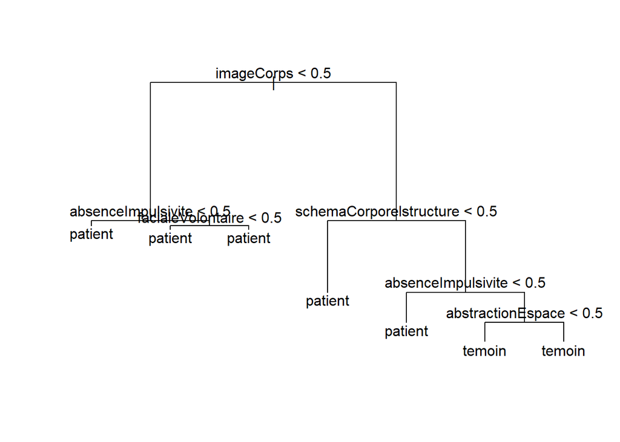

```
## node), split, n, deviance, yval, (yprob)
##       * denotes terminal node
##
##  1) root 98 135.500 patient ( 0.46939 0.53061 )
##    2) imageCorps < 0.5 38   9.249 patient ( 0.02632 0.97368 )
##      4) absenceImpulsivite < 0.5 25   0.000 patient ( 0.00000 1.00000 ) *
##      5) absenceImpulsivite > 0.5 13   7.051 patient ( 0.07692 0.92308 )
##       10) facialeVolontaire < 0.5 7   0.000 patient ( 0.00000 1.00000 ) *
##       11) facialeVolontaire > 0.5 6   5.407 patient ( 0.16667 0.83333 ) *
##    3) imageCorps > 0.5 60  67.480 temoin ( 0.75000 0.25000 )
##      6) schemaCorporelstructure < 0.5 9   0.000 patient ( 0.00000 1.00000 ) *
##      7) schemaCorporelstructure > 0.5 51  36.950 temoin ( 0.88235 0.11765 )
##       14) absenceImpulsivite < 0.5 6   7.638 patient ( 0.33333 0.66667 ) *
##       15) absenceImpulsivite > 0.5 45  16.360 temoin ( 0.95556 0.04444 )
##         30) abstractionEspace < 0.5 7   8.376 temoin ( 0.71429 0.28571 ) *
##         31) abstractionEspace > 0.5 38   0.000 temoin ( 1.00000 0.00000 ) *
```

```
##          pred
## true      temoin patient
##   temoin      25       0
##   patient      0      25
```

```
##          pred
## true      temoin patient
##   temoin      21       4
##   patient      1      24
```

```
##          pred
## true      temoin patient
##   temoin      25       0
##   patient      1      24
```

## Méthode 5 : méthode KNN (des k plus proches voisins)

Cette méthode ayant une taux d’erreurs élevée, elle a pour avantage qu’elle ne se trompe prèsque jamais chez les témoins, car les témoins sont spacialement très troches les uns des autres, au contraires des patients.

```
##             Length Class      Mode
## learn        2     -none-     list
## k            1     -none-     numeric
## theDots      0     -none-     list
## xNames      26     -none-     character
## problemType  1     -none-     character
## tuneValue    1     data.frame list
## obsLevels    2     -none-     character
## param        0     -none-     list
```

```
## k-Nearest Neighbors
##
## 98 samples
## 26 predictors
##  2 classes: 'temoin', 'patient'
##
## Pre-processing: centered (26), scaled (26)
## Resampling: Cross-Validated (10 fold, repeated 3 times)
## Summary of sample sizes: 88, 89, 88, 89, 88, 87, ...
## Resampling results across tuning parameters:
##
##   k   Accuracy   Kappa
##    5  0.7864310  0.5813017
##    7  0.7663636  0.5416241
##    9  0.7630303  0.5349574
##   11  0.7663636  0.5416241
##   13  0.7526599  0.5151683
##   15  0.7459933  0.5018350
##   17  0.7422896  0.4948663
##   19  0.7422896  0.4948663
##   21  0.7322896  0.4748663
##   23  0.7288889  0.4694321
##   25  0.7318519  0.4757968
##   27  0.7318519  0.4757968
##
## Accuracy was used to select the optimal model using  the largest value.
## The final value used for the model was k = 5.
```

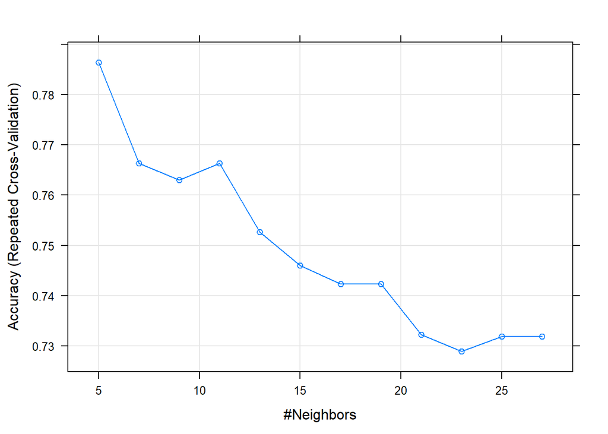

```
##          pred
## true      temoin patient
##   temoin      25       0
##   patient      4      21
```

```
##          pred
## true      temoin patient
##   temoin      25       0
##   patient      5      20
```

```
##          pred
## true      temoin patient
##   temoin      25       0
##   patient      8      17
```